# BLS Data Project Case Study

Greg York

2022-06-03

## Case Study Introduction

For my capstone project for the Google Certificate in Data Analytics on Coursera, I wanted to try something a bit different than the provided business cases. I’ve always been interested in policy, and the use of data to inform our understanding of people and societal trends.

One of the public data sets the course recommended was from the [BLS](https://www.bls.gov/cps/tables.htm). It includes historical data concerning labor force statistics, with some data reaching back as far as 1936.

This case study is more of a data exploration. I am getting practice in locating, downloading, cleaning, organizing, loading, transforming, plotting, and publishing using a variety of tools, including R (and RStudio).

**Note! This is very basic so far, I am just getting started. There are no earthshattering findings here. Just getting my feet wet.**

### The Setup

First thing, I have to load the packages I’ll need for the analysis. So far, I have been leaning heavily on the package ‘tidyverse’. Dealing with all of this Excel data, I have been using ‘readxl’ to (some) success.

```r
library(tidyverse)
library(readxl)
```

Some of the data on the BLS website is not in spreadsheet format. The text files included are not delineated in any way (they are designed to be human-readable) so importing that data using base R or the library ‘readr’ proved impossible (for me). So that seemed like a dead-end.

The PDFs were also a challenge. The data looks like it’s in a tabular form. The library ‘tabulizer’ would be useful, but it has not been updated in quite awhile and would not load in my version of R. Instead, I used a utility called [Tabula](https://tabula.technology/) which managed to pull most of what I needed from the PDFs into a .csv format so I could clean it up in Excel or R to use.

## First Data Set, First Plot

So just to get my feet wet, I went ahead and looked at the first table on the BLS website, on Employment Status. This XLSX file has general employment trends reaching back to 1951.

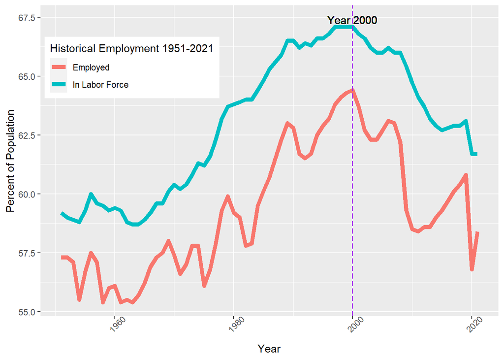

Clearly, something happens right around year 2000. At the time, wages are increasing (outpacing inflation), quality of jobs are increasing, more jobs have health insurance - these are signs of a tight labor market, which boosted participation rates. [Source](https://www.epi.org/publication/books_swa2000_swa2000intro/)

But after 2000, the percentage of Americans in the labor force begins an inexorable decline, along with the percentage of Americans employed. Why does this happen?

What I would like to do is explore the differences between a variety of labor and work-force factors in 1999 and compare them to today (2021).

## Second Data Set, Second Plot

The first thing I’m going to look at are the people who are NOT in the labor force. Some of the decline will undoubtedly be due to the aging of the population in the US. Can I find that in the statistics from the BLS?

For the 1999 dataset, I need Tabula (referenced above) to pull the data from the PDF and drop it into an Excel spreadsheet I can clean up. I combined the 1999 and 2021 data into one spreadsheet (which turned out to be a mistake!) and produced this chart:

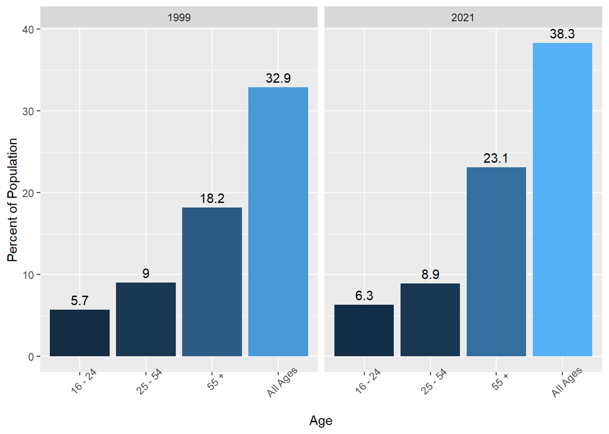

Here we see one of the drivers of the decrease in percentage of the population in the labor force. Virtually the entire increase in non-workforce participation is in those aged 55 and over.